# Olympics_EDA

```
'data.frame':   133965 obs. of  25 variables:
 $ X           : int  1 2 3 4 5 6 7 8 9 10 ...
 $ NOC         : Factor w/ 122 levels "AFG","ALB","AND",..: 1 1 1 1 1 1 1 1 1 1 ...
 $ Year        : int  1960 1960 1960 1960 1960 1960 1960 1960 1960 1960 ...
 $ Decade      : Factor w/ 6 levels "1960s","1970s",..: 1 1 1 1 1 1 1 1 1 1 ...
 $ ID          : int  59346 59043 109486 59102 128736 29626 39922 106372 128736 58364 ...
 $ First.Name  : Factor w/ 14118 levels "","A","A.","Aadam",..: 8716 3731 64 599 64 11978 64 4634 64 8716 ...
 $ Name        : Factor w/ 74268 levels "  Gabrielle Marie \"Gabby\" Adcock (White-)",..: 48941 19066 219 3341 221 64833 216 23793 221 48946 ...
 $ Last.Name   : Factor w/ 47370 levels "","-)","-Alard)",..: 23228 23112 38893 23137 44908 13260 16633 37860 44908 22890 ...
 $ Sex         : Factor w/ 2 levels "F","M": 2 2 2 2 2 2 2 2 2 2 ...
 $ Age         : int  24 18 20 35 20 28 22 23 20 20 ...
 $ Height      : int  171 162 178 166 179 168 172 170 179 166 ...
 $ Weight      : num  78 52 68 66 75 73 70 58 75 62 ...
 $ BMI         : num  26.7 19.8 21.5 24 23.4 ...
 $ BMI.Category: int  3 0 2 2 2 3 2 2 2 2 ...
 $ Team        : Factor w/ 332 levels "Acipactli","Afghanistan",..: 2 2 2 2 2 2 2 2 2 2 ...
 $ Population  : int  8996973 8996973 8996973 8996973 8996973 8996973 8996973 8996973 8996973 8996973 ...
 $ GDP         : num  5.38e+08 5.38e+08 5.38e+08 5.38e+08 5.38e+08 ...
 $ GDPpC       : num  59.8 59.8 59.8 59.8 59.8 ...
 $ Games       : Factor w/ 30 levels "1960 Summer",..: 1 1 1 1 1 1 1 1 1 1 ...
 $ Season      : Factor w/ 2 levels "Summer","Winter": 1 1 1 1 1 1 1 1 1 1 ...
 $ City        : Factor w/ 29 levels "Albertville",..: 19 19 19 19 19 19 19 19 19 19 ...
 $ Sport       : Factor w/ 51 levels "Alpine Skiing",..: 51 51 3 51 3 51 3 3 3 51 ...
 $ Event       : Factor w/ 489 levels "Alpine Skiing Men's Combined",..: 478 468 17 476 33 482 22 24 18 466 ...
 $ Medal       : Factor w/ 4 levels "Bronze","Gold",..: 3 3 3 3 3 3 3 3 3 3 ...
 $ Medal.No.Yes: int  0 0 0 0 0 0 0 0 0 0 ...
 - attr(*, "na.action")= 'omit' Named int  17 19 20 21 22 23 31 32 33 35 ...
  ..- attr(*, "names")= chr  "17" "19" "20" "21" ...
```

#Olympics Correlation plot

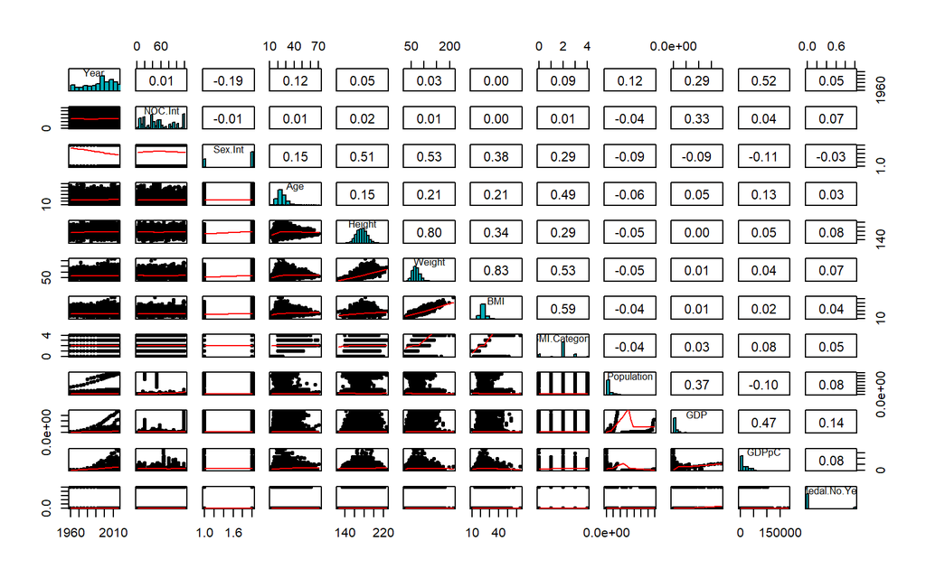

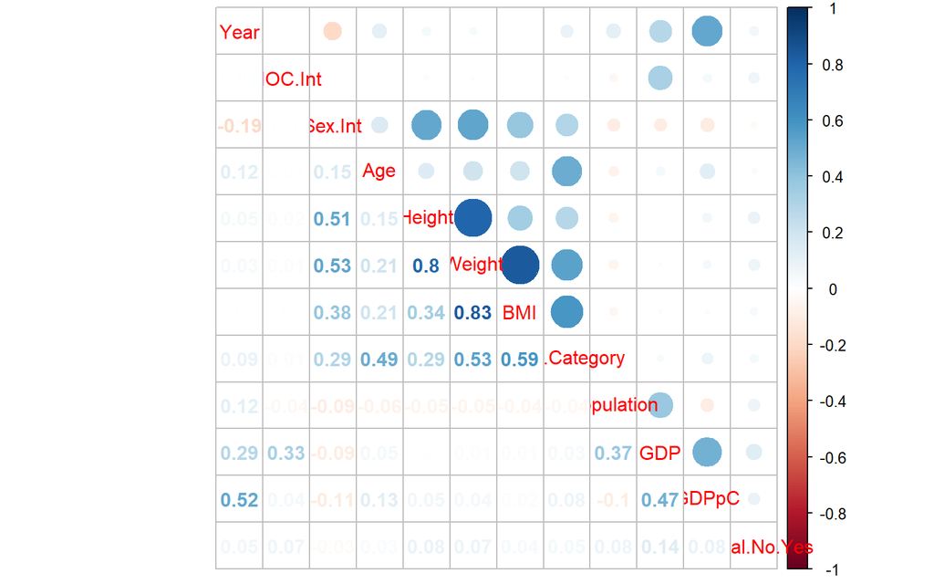

# Olympics 1915-1925. First World War (1914-18) and 1918 (H1N1) Pandemic (aka Spanish Flu)

[https://www.ncbi.nlm.nih.gov/books/NBK22148/] (https://www.ncbi.nlm.nih.gov/books/NBK22148/) The following countries in Europe had 2.64 million excess deaths occurred during the period when the H1N1 Pandemic (Spanish Flu) was circulating from January 1918 - June 1919: Italy, Bulgaria, Portugal, Spain, Netherlands, Sweden, Germany, Switzerland, France, Norway, Denmark, UK (Scotland, England, Wales). In the US, 675,000 people died from H1N1 which nearly was 0.8 percent of the 1910 population.

(JOHNSON, NIALL P. A. S., and JUERGEN MUELLER. “Updating the Accounts: Global Mortality of the 1918-1920 ‘Spanish’ Influenza Pandemic.” Bulletin of the History of Medicine, vol. 76, no. 1, 2002, pp. 105–115. JSTOR, www.jstor.org/stable/44446153. Accessed 19 Apr. 2020.)

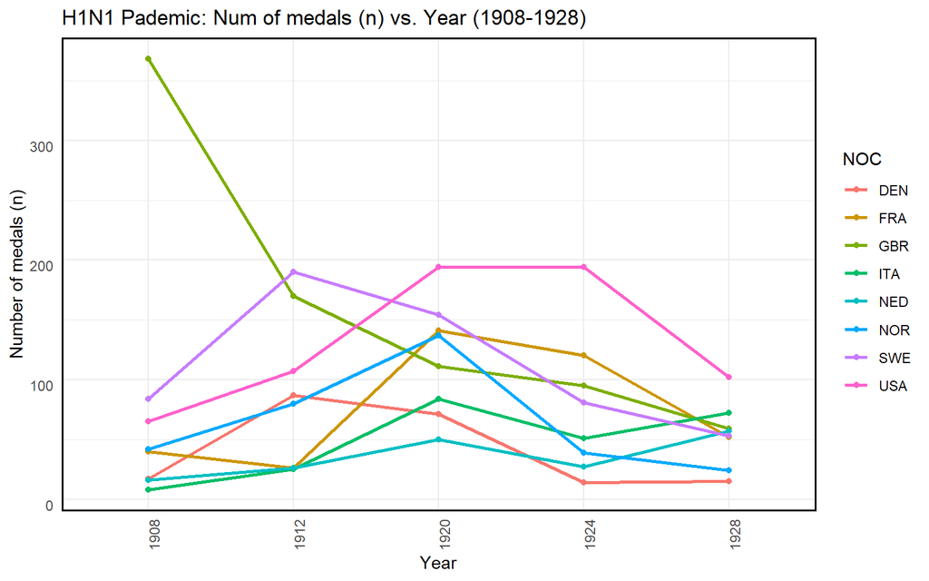

[figure not shown]

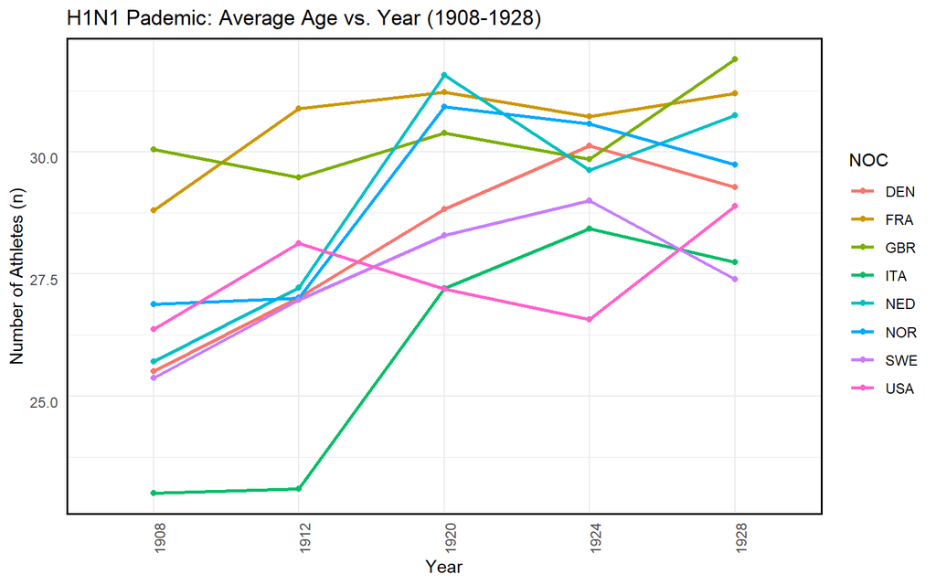

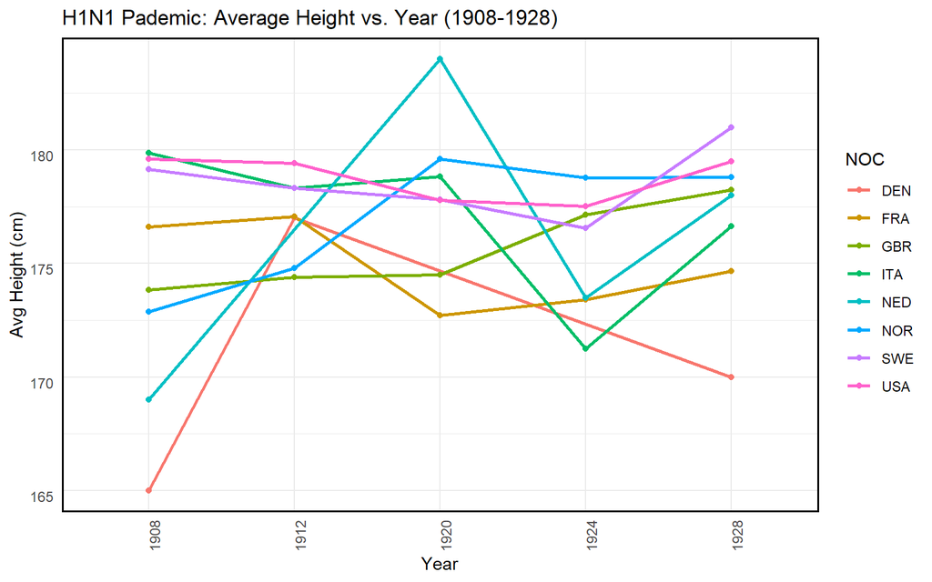

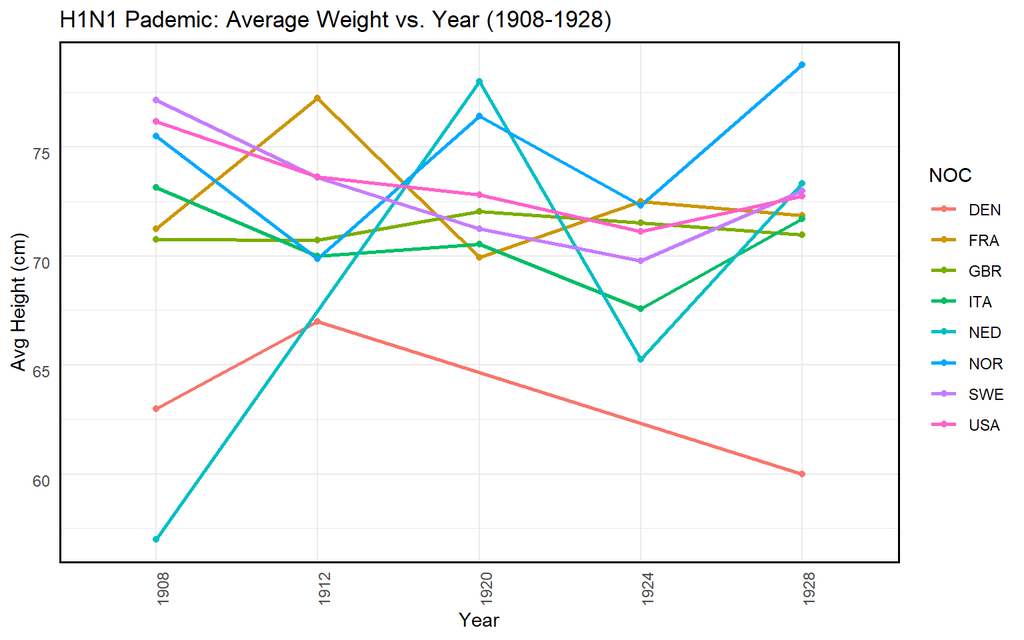

# Model Building

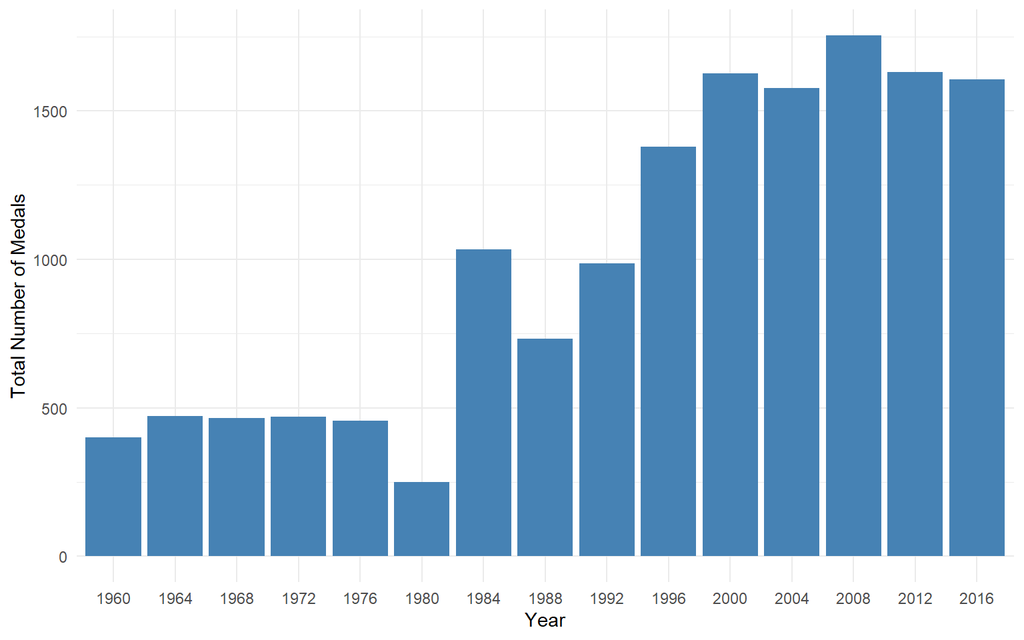

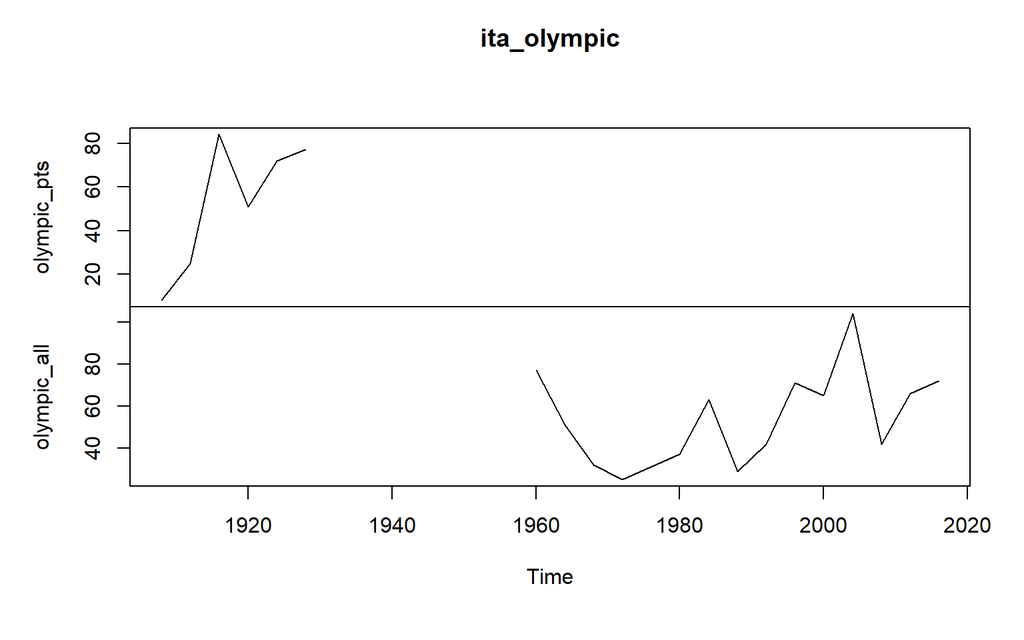

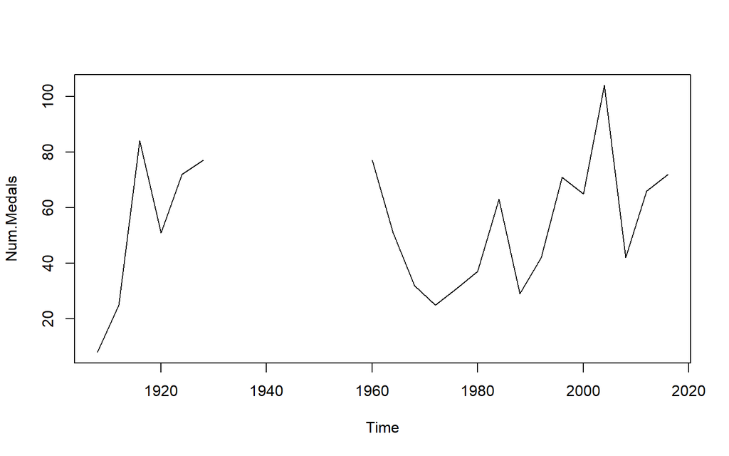

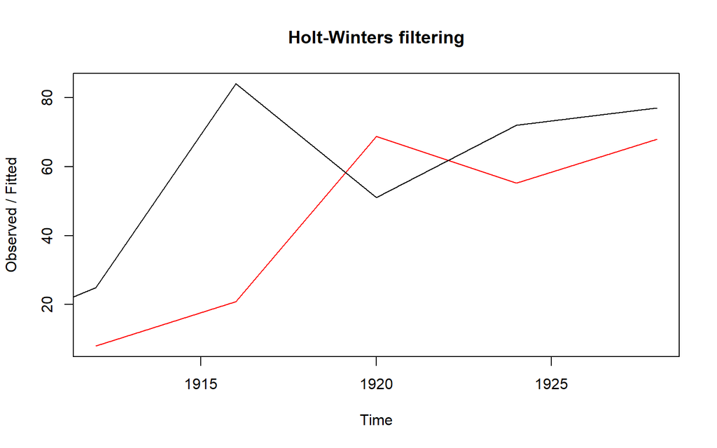

```
             Length Class  Mode
fitted       10     mts    numeric
x             6     ts     numeric
alpha         1     -none- numeric
beta          1     -none- logical
gamma         1     -none- logical
coefficients  1     -none- numeric
seasonal      1     -none- character
SSE           1     -none- numeric
call          4     -none- call
```

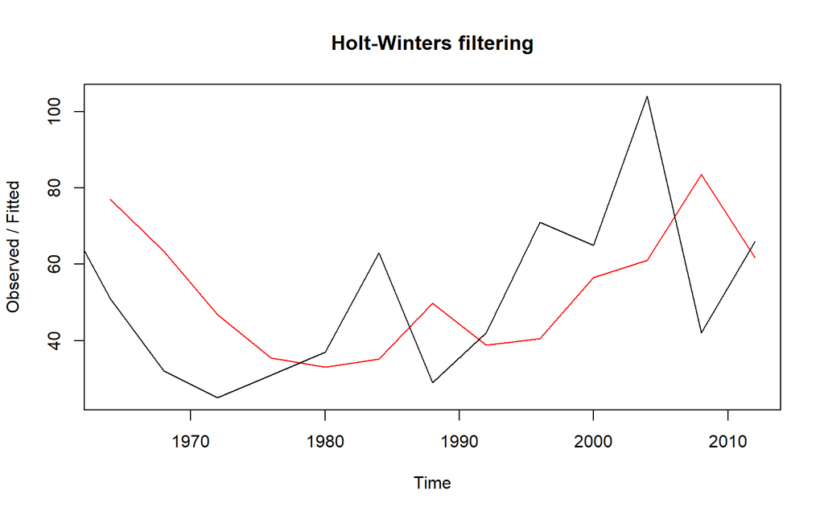

```
             Length Class  Mode
fitted       26     mts    numeric
x            14     ts     numeric
alpha         1     -none- numeric
beta          1     -none- logical
gamma         1     -none- logical
coefficients  1     -none- numeric
seasonal      1     -none- character
SSE           1     -none- numeric
call          4     -none- call
```

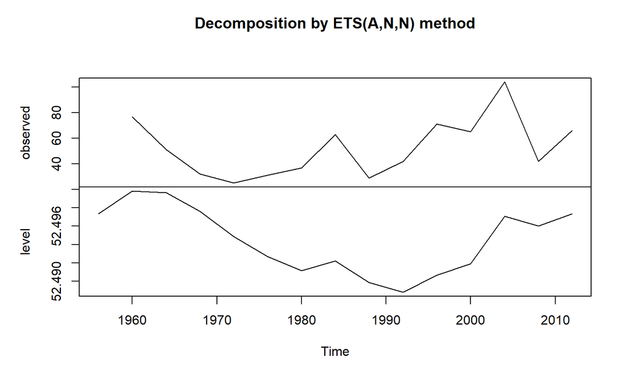

```
     Point Forecast Lo 80 Hi 80 Lo 95 Hi 95
2016           52.5  22.2  82.8  6.19  98.8
2020           52.5  22.2  82.8  6.19  98.8
2024           52.5  22.2  82.8  6.19  98.8
```

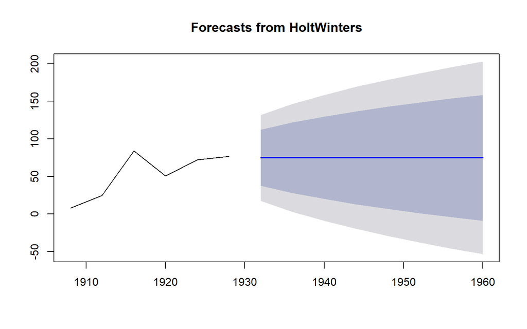

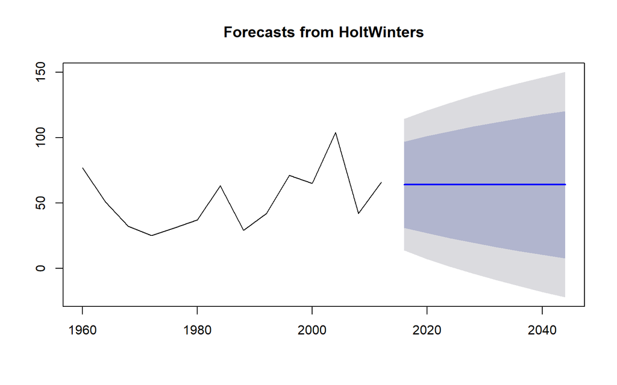

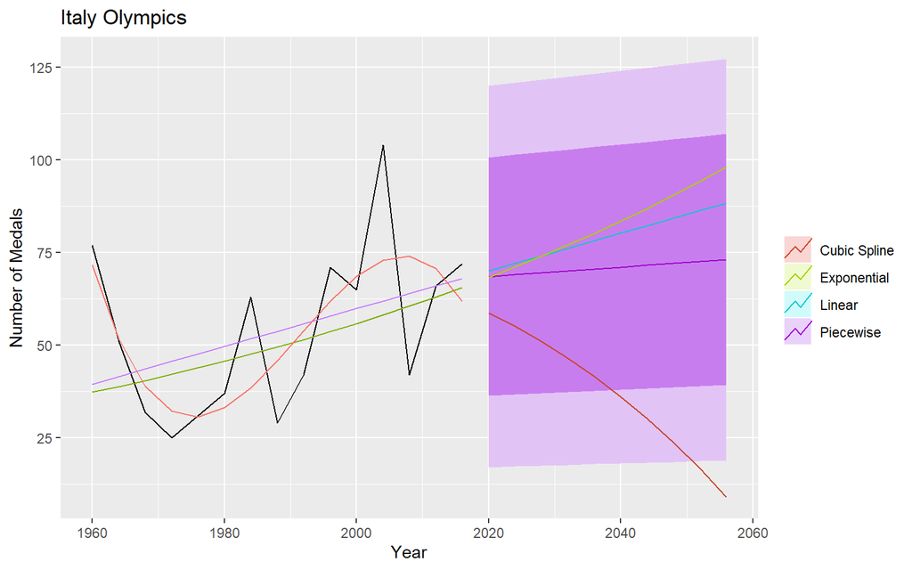

```
Series: olympic_all
ARIMA(0,0,0) with non-zero mean

Coefficients:
      mean
      53.8
s.e.   5.6

sigma^2 estimated as 504:  log likelihood=-67.4
AIC=139   AICc=140   BIC=140

Training set error measures:
                   ME RMSE  MAE   MPE MAPE MASE  ACF1
Training set 9.95e-15 21.7 18.9 -18.1 41.8 0.35 0.228
```

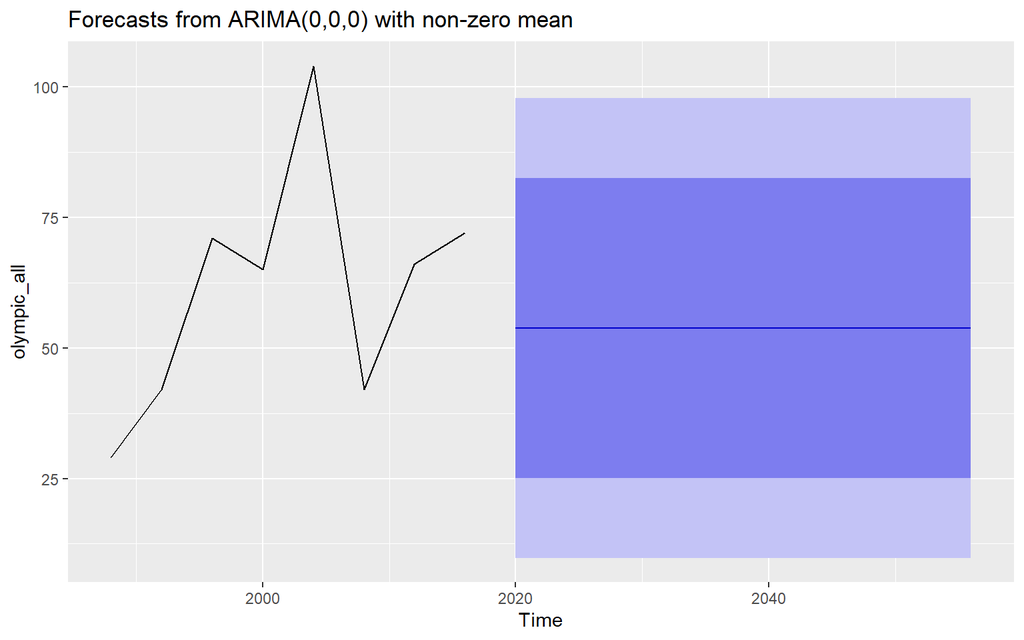

## Linear Model #Create New_data Adding Total Number of Medals

### Linear Model1 TMedals ~ BMI

```
Call:
lm(formula = dyn(TMedals ~ BMI), data = new_data)

Residuals:
   Min     1Q Median     3Q    Max
  -932   -611    204    447    675

Coefficients:
            Estimate Std. Error t value Pr(>|t|)
(Intercept)  1250.46      29.95   41.76   <2e-16 ***
BMI            -3.39       1.29   -2.63   0.0086 **
---
Signif. codes:  0 '***' 0.001 '**' 0.01 '*' 0.05 '.' 0.1 ' ' 1

Residual standard error: 512 on 17973 degrees of freedom
Multiple R-squared:  0.000383,  Adjusted R-squared:  0.000328
F-statistic:  6.9 on 1 and 17973 DF,  p-value: 0.00865
```

Linear model summary

|  | Estimate | Std. Error | t value | Pr(>\|t\|) |
| --- | --- | --- | --- | --- |
| (Intercept) | 1250.46 | 29.95 | 41.76 | 0.0000 |
| BMI | -3.39 | 1.29 | -2.63 | 0.0086 |

VIFs of the model

|  | VIF |
| --- | --- |
| BMI | 1 |

### Linear Model2 TMedals ~ Age

```
Call:
lm(formula = dyn(TMedals ~ Age), data = new_data)

Residuals:
   Min     1Q Median     3Q    Max
 -1021   -598    203    443    646

Coefficients:
            Estimate Std. Error t value Pr(>|t|)
(Intercept)  1013.26      19.51   51.94   <2e-16 ***
Age             6.24       0.75    8.32   <2e-16 ***
---
Signif. codes:  0 '***' 0.001 '**' 0.01 '*' 0.05 '.' 0.1 ' ' 1

Residual standard error: 511 on 17973 degrees of freedom
Multiple R-squared:  0.00384,   Adjusted R-squared:  0.00378
F-statistic: 69.3 on 1 and 17973 DF,  p-value: <2e-16
```

```
Age
  1
```

Linear model2 summary

|  | Estimate | Std. Error | t value | Pr(>\|t\|) |
| --- | --- | --- | --- | --- |
| (Intercept) | 1013.26 | 19.51 | 51.94 | 0 |
| Age | 6.24 | 0.75 | 8.32 | 0 |

VIFs of the model

|  | VIF |
| --- | --- |
| Age | 1 |

### Linear Model 3 TMedals ~ BMI + Age

```
Call:
lm(formula = dyn(TMedals ~ BMI + Age), data = new_data)

Residuals:
   Min     1Q Median     3Q    Max
 -1032   -597    203    444    759

Coefficients:
            Estimate Std. Error t value Pr(>|t|)
(Intercept) 1125.573     32.973   34.14  < 2e-16 ***
BMI           -5.531      1.309   -4.22  2.4e-05 ***
Age            6.833      0.763    8.96  < 2e-16 ***
---
Signif. codes:  0 '***' 0.001 '**' 0.01 '*' 0.05 '.' 0.1 ' ' 1

Residual standard error: 511 on 17972 degrees of freedom
Multiple R-squared:  0.00483,   Adjusted R-squared:  0.00472
F-statistic: 43.6 on 2 and 17972 DF,  p-value: <2e-16
```

Linear model3 summary

|  | Estimate | Std. Error | t value | Pr(>\|t\|) |
| --- | --- | --- | --- | --- |
| (Intercept) | 1125.57 | 32.973 | 34.14 | 0 |
| BMI | -5.53 | 1.309 | -4.22 | 0 |
| Age | 6.83 | 0.763 | 8.96 | 0 |

VIFs of the model

|  | VIF |
| --- | --- |
| Age | 1.03 |
| BMI | 1.03 |

### Linear Model 4 TMedals ~ BMI + Age + GDP

```
Call:
lm(formula = dyn(TMedals ~ BMI + Age + GDP), data = new_data)

Residuals:
   Min     1Q Median     3Q    Max
 -1155   -541    107    462    822

Coefficients:
             Estimate Std. Error t value Pr(>|t|)
(Intercept)  1.06e+03   3.23e+01   32.82  < 2e-16 ***
BMI         -5.57e+00   1.28e+00   -4.36  1.3e-05 ***
Age          6.89e+00   7.45e-01    9.24  < 2e-16 ***
GDP          2.55e-11   8.68e-13   29.37  < 2e-16 ***
---
Signif. codes:  0 '***' 0.001 '**' 0.01 '*' 0.05 '.' 0.1 ' ' 1

Residual standard error: 499 on 17971 degrees of freedom
Multiple R-squared:  0.0504,    Adjusted R-squared:  0.0503
F-statistic:  318 on 3 and 17971 DF,  p-value: <2e-16
```

Linear model4 summary

|  | Estimate | Std. Error | t value | Pr(>\|t\|) |
| --- | --- | --- | --- | --- |
| (Intercept) | 1059.67 | 32.288 | 32.82 | 0 |
| BMI | -5.57 | 1.279 | -4.36 | 0 |
| Age | 6.89 | 0.745 | 9.24 | 0 |
| GDP | 0.00 | 0.000 | 29.37 | 0 |

VIFs of the model

|  | VIF |
| --- | --- |
| Age | 1.03 |
| BMI | 1.03 |
| GDP | 1.00 |

|  | Adjusted R2 |
| --- | --- |
| Linear Model 1: TMedals ~ BMI | 0.000 |
| Linear Model 2: TMedals ~ Age | 0.004 |
| Linear Model 3: TMedals ~ BMI + Age | 0.005 |
| Linear Model 4: TMedals ~ BMI + Age+ GDP | 0.050 |

```
Analysis of Variance Table

Model 1: TMedals ~ BMI
Model 2: TMedals ~ Age
Model 3: TMedals ~ BMI + Age
Model 4: TMedals ~ BMI + Age + GDP
  Res.Df      RSS Df Sum of Sq     F  Pr(>F)
1  17973 4.71e+09
2  17973 4.69e+09  0  1.63e+07
3  17972 4.69e+09  1  4.65e+06  18.7 1.5e-05 ***
4  17971 4.47e+09  1  2.15e+08 862.6 < 2e-16 ***
---
Signif. codes:  0 '***' 0.001 '**' 0.01 '*' 0.05 '.' 0.1 ' ' 1
```

```
     Res.Df           RSS                 Df          Sum of Sq
 Min.   :17971   Min.   :4.47e+09   Min.   :0.000   Min.   :4.65e+06
 1st Qu.:17972   1st Qu.:4.63e+09   1st Qu.:0.500   1st Qu.:1.05e+07
 Median :17972   Median :4.69e+09   Median :1.000   Median :1.63e+07
 Mean   :17972   Mean   :4.64e+09   Mean   :0.667   Mean   :7.86e+07
 3rd Qu.:17973   3rd Qu.:4.70e+09   3rd Qu.:1.000   3rd Qu.:1.15e+08
 Max.   :17973   Max.   :4.71e+09   Max.   :1.000   Max.   :2.15e+08
                                    NA's   :1       NA's   :1
       F           Pr(>F)
 Min.   : 19   Min.   :0
 1st Qu.:230   1st Qu.:0
 Median :441   Median :0
 Mean   :441   Mean   :0
 3rd Qu.:652   3rd Qu.:0
 Max.   :863   Max.   :0
 NA's   :2     NA's   :2
```

# Logit Regression: Factors influencing Earning Olympic Medals

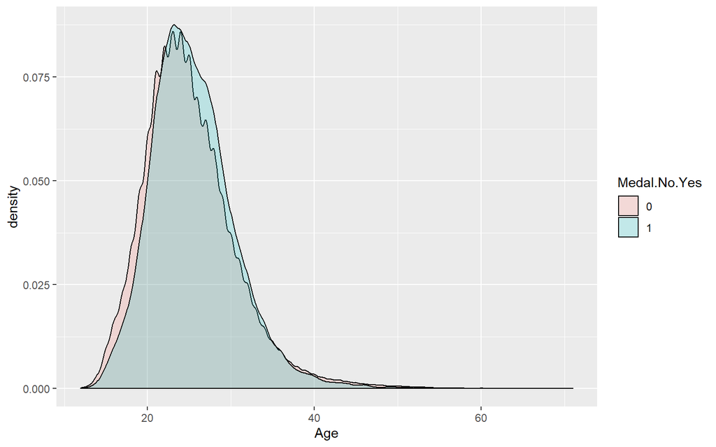

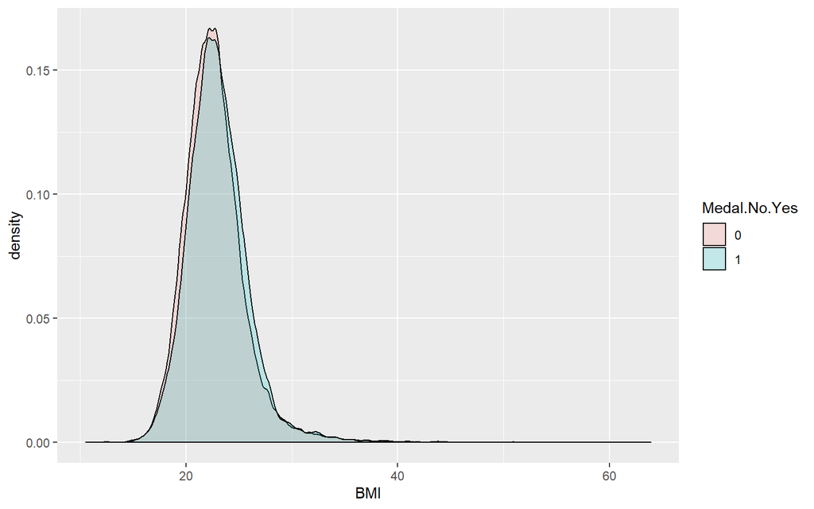

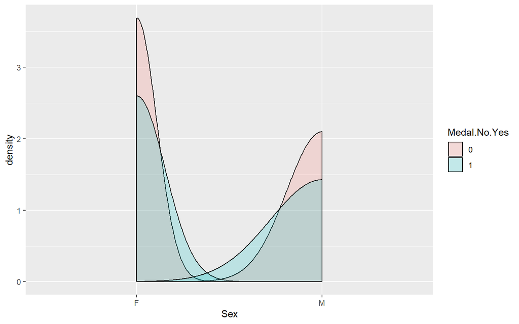

```
Call:
glm(formula = Medal.No.Yes ~ BMI + Age + Sex, family = binomial(link = "logit"),
    data = new_data_subset)

Deviance Residuals:
   Min      1Q  Median      3Q     Max
-1.226  -0.555  -0.520  -0.488   2.233

Coefficients:
            Estimate Std. Error z value Pr(>|z|)
(Intercept) -3.12303    0.06522  -47.88  < 2e-16 ***
BMI          0.05111    0.00277   18.47  < 2e-16 ***
Age          0.01162    0.00145    8.03  9.8e-16 ***
SexM        -0.31945    0.01792  -17.82  < 2e-16 ***
---
Signif. codes:  0 '***' 0.001 '**' 0.01 '*' 0.05 '.' 0.1 ' ' 1

(Dispersion parameter for binomial family taken to be 1)

    Null deviance: 105631  on 133964  degrees of freedom
Residual deviance: 105073  on 133961  degrees of freedom
AIC: 105081

Number of Fisher Scoring iterations: 4
```

```
(Intercept)         BMI         Age        SexM
      0.044       1.052       1.012       0.727
```

```
               2.5 %  97.5 %
(Intercept) -3.25087 -2.9952
BMI          0.04569  0.0565
Age          0.00878  0.0145
SexM        -0.35457 -0.2843
```

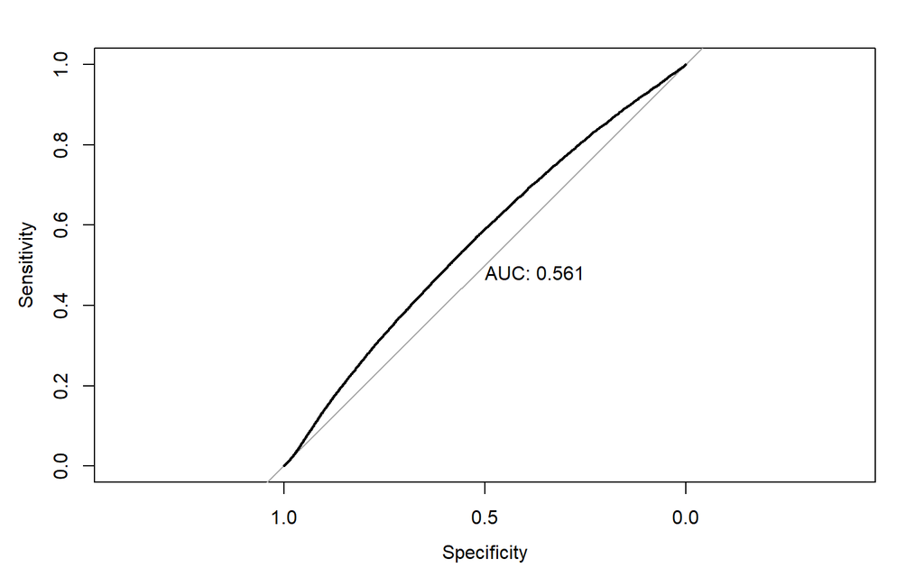

Confusion Matrix: Logit model 2, cutoff = 0.5

|  | Predicted 0 | Predicted 1 | Total |
| --- | --- | --- | --- |
| Actual 0 | 115988 | 2 | 115990 |
| Actual 1 | 17975 | 0 | 17975 |
| Total | 133963 | 2 | 133965 |

```
fitting null model for pseudo-r2
```

```
      llh   llhNull        G2  McFadden      r2ML      r2CU
-5.25e+04 -5.28e+04  5.59e+02  5.29e-03  4.16e-03  7.63e-03
```

The McFadden (part of the pseudo-R$^2$ statistics) value of 0.005 also shows the model is not a particularly great model, with only 0.5% of the variation explained.

LNT

04/25/2020